# reproduciblepaperswithR

Nicole Trenholm, nicolet3@umcb.edu

1/18/2019

# Introduction

We love to use (RStudio Team 2015) for reproducible papers.

# Methods

Our analysis will be pretty simple. We’ll use the `diamonds` dataset from the `ggplot2` (Wickham 2009) package and run a simple linear model. At the top of this document, we started with a code chunk with `echo=FALSE` set as a chunk option so that we can load the `ggplot2` package and `diamonds` dataset without outputting anything to the screen.

For our analysis, we’ll create a really great plot which really shows the relationship between price and carat and shows how we include plots in our document. Then we’ll run a linear model of the form $y = mx + b$ on the relationship between price and carat and shows how we include tables in our document. We can also put some more advanced math in our paper and it will be beautifully typeset:

$$\sum_{i=1}^{N}{log(i) + \frac{\omega}{x}}$$

# Results

The plot we made was really great (Figure 1).

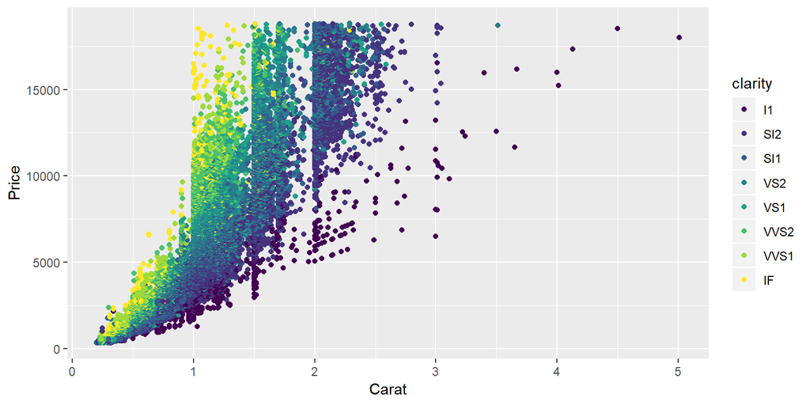

Figure 1: The relationship between price and carat for the diamonds dataset.

But the model was even better:

Table 1: This is a broomed linear model summary table.

| term | estimate | std.error | statistic | p.value |
| --- | --- | --- | --- | --- |
| (Intercept) | -2256.36 | 13.06 | -172.83 | 0 |
| carat | 7756.43 | 14.07 | 551.41 | 0 |

We were delighted to find that the slope parameter was 7756.43.

# Discussion

This was just a quick demonstration of a reproducible paper that combined text, analysis, figures, tables, and citations into multiple output formats (HTML, PDF). Hopefully you found it useful.

A lot of people are using RMarkdown these days so there are tons of resources online but here are a few choice ones specifically about making papers:

- http://rmarkdown.rstudio.com/authoring_bibliographies_and_citations.html
- http://svmiller.com/blog/2016/02/svm-r-markdown-manuscript/
- http://www.petrkeil.com/?p=2401

# References

RStudio Team. 2015. *RStudio: Integrated Development Environment for R*. Boston, MA: RStudio, Inc. http://www.rstudio.com/.

Wickham, Hadley. 2009. *Ggplot2: Elegant Graphics for Data Analysis*. Springer-Verlag New York. http://ggplot2.org.